# Análisis Exploratorio de Datos - Taller Individual 2, Universidad ICESI

Jorge Antonio Morales

3/3/2022

## Primera pregunta

### ¿Cuál es el perfil de ingreso de los estudiantes?

Para este caso se realizará un análisis univariado de las variables que se especifican en el taller:

#### Género

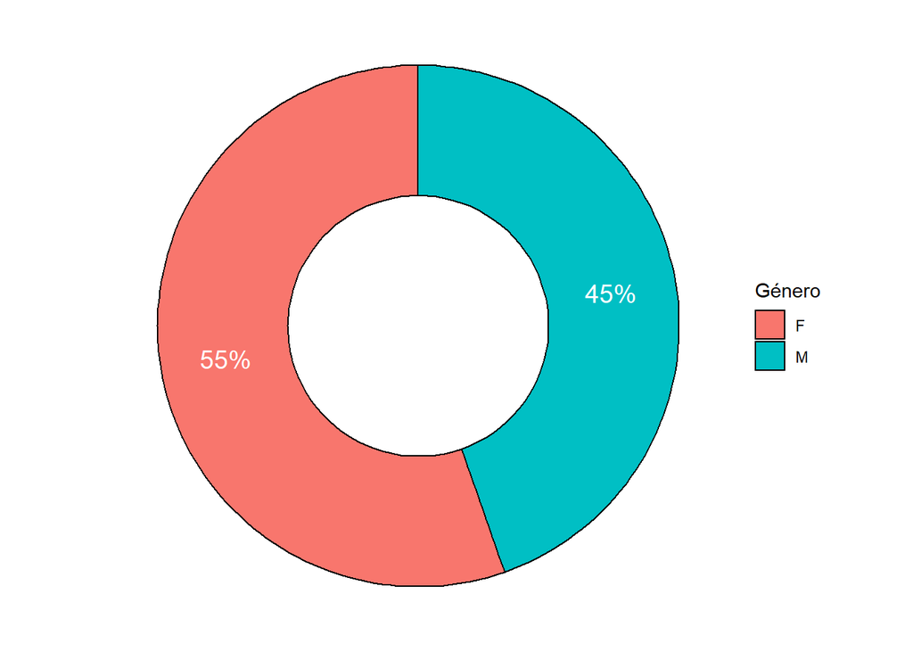

La mayoría de los estudiantes son mujeres, pero su proporción es bastante equitativa.

#### Estrato

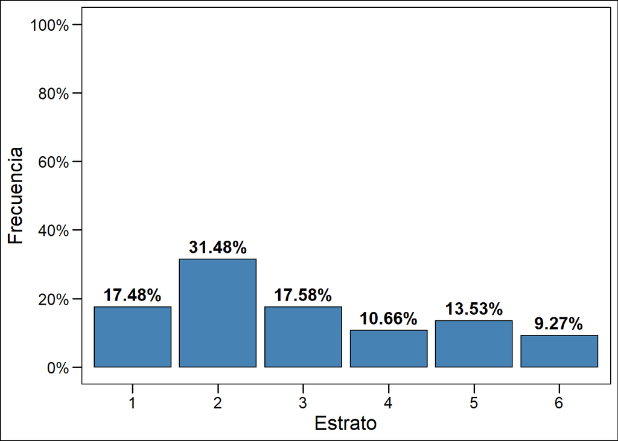

La mayoría de los estudiantes pertenecen al estrato número dos y la minoría al estrato seis.

#### Edad_entrada

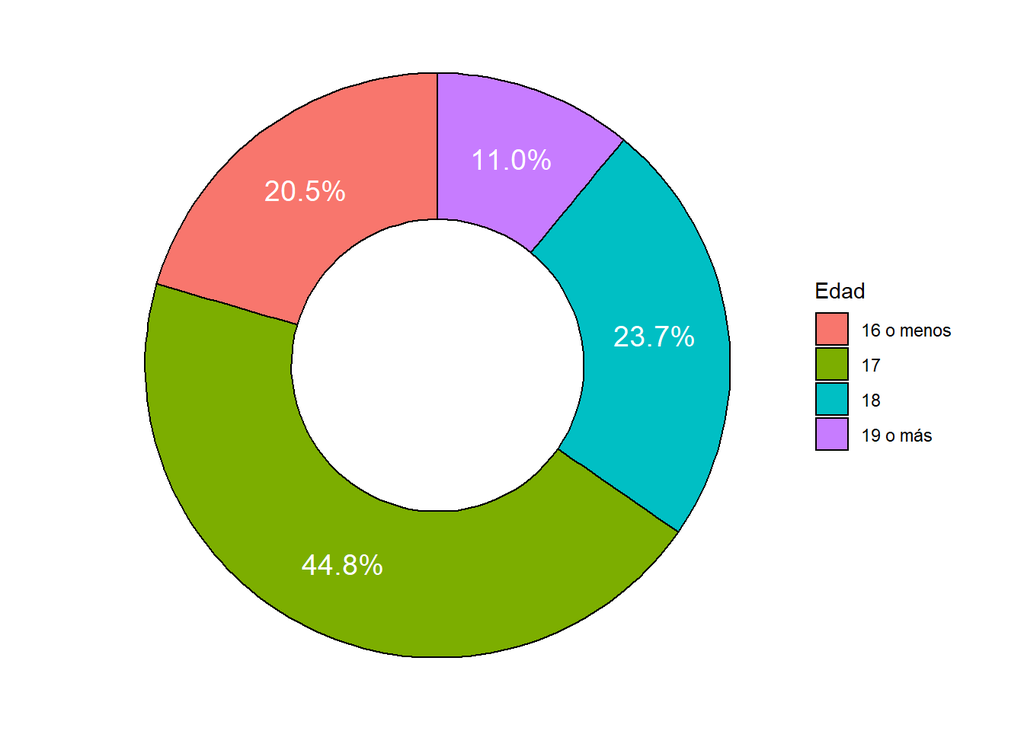

La mayoría de los estudiantes tienen 17 años y la minoría tiene 19 o más años.

#### Ciudad de procedencia

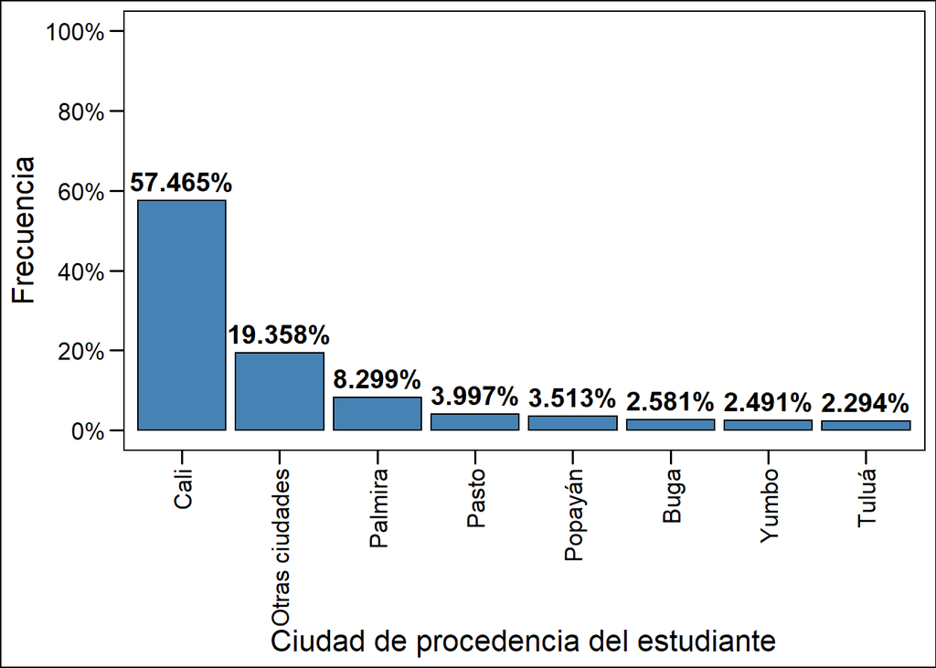

La mayoría de los estudiantes son de Cali, además, la gran minoría provienen de Pasto, Popayán, Buga, Yumbo y Tuluá.

#### Puntaje Global

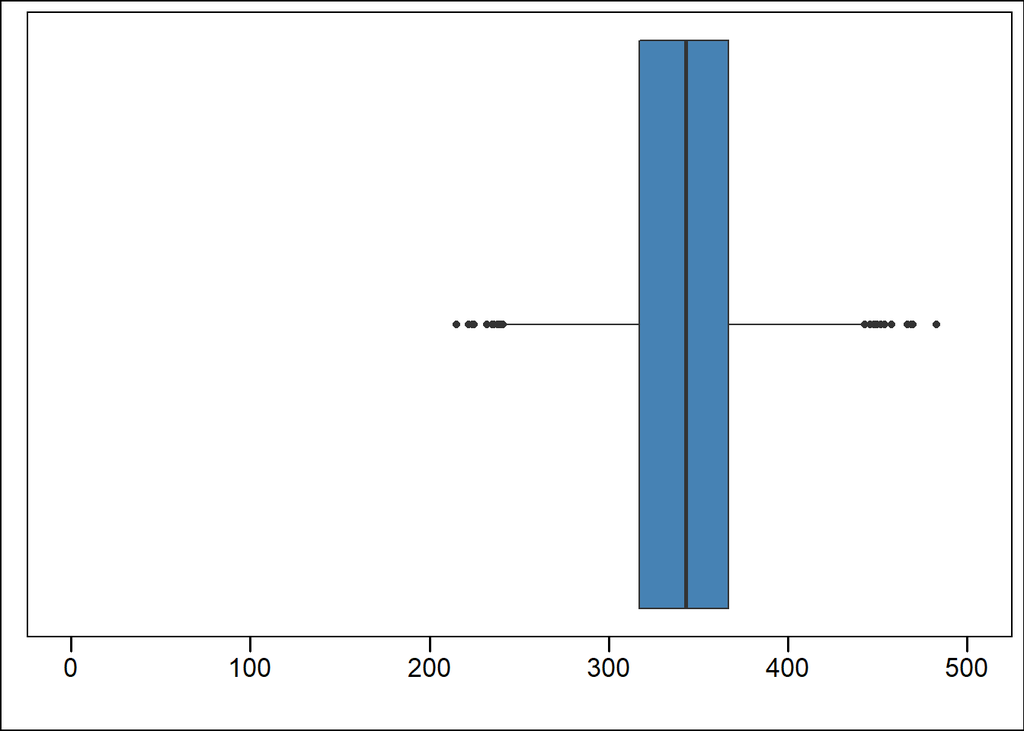

Del diagrama de cajas podemos resaltar que los estudiantes tienden a sacar un puntaje global entre los 300 y 400 puntos, con una mediana y media de 343 puntos.

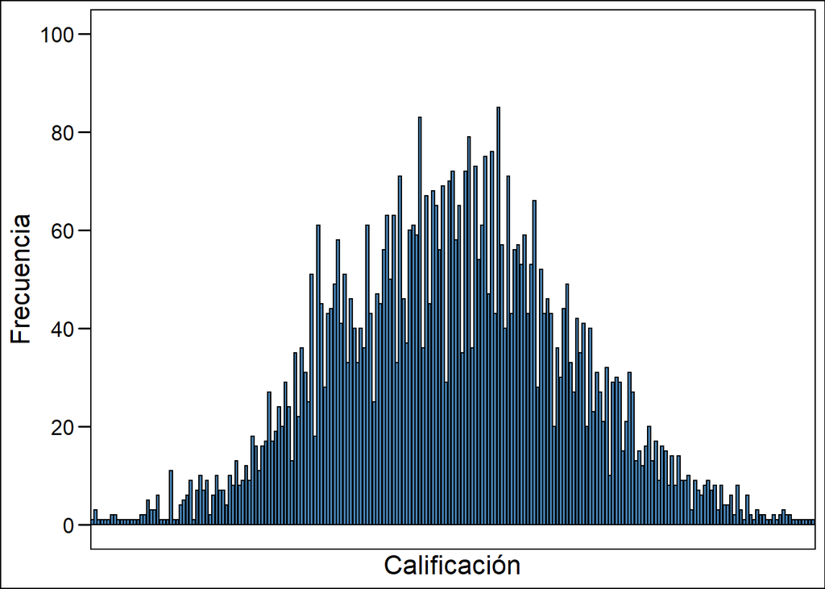

#### Facultad

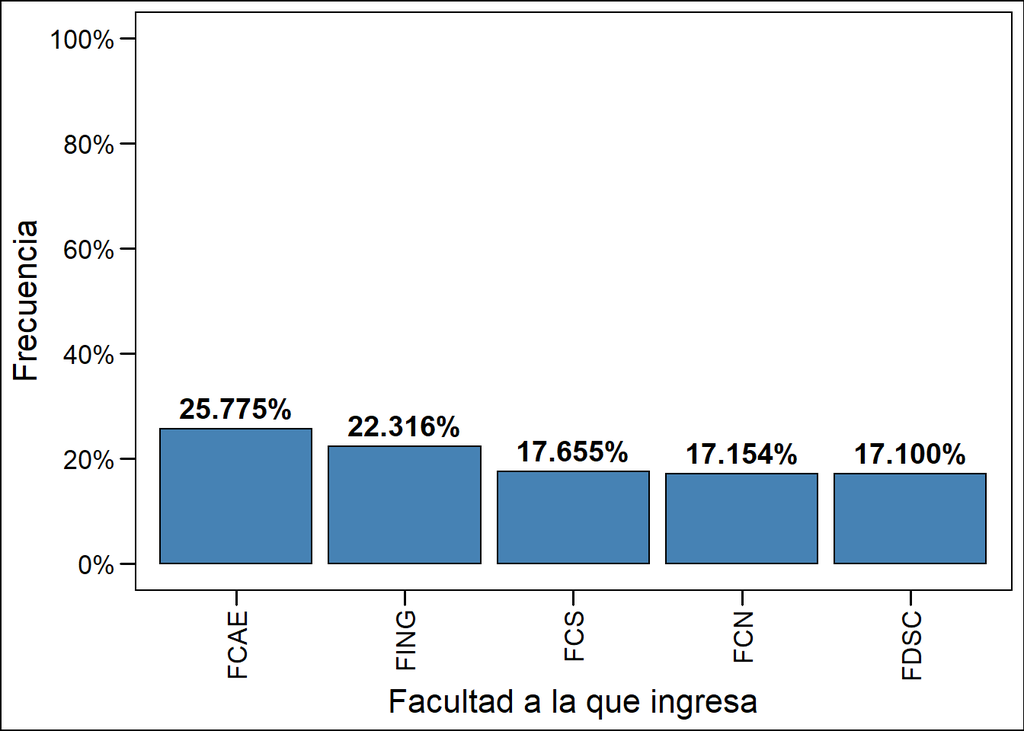

La proporción de estudiantes en las facultades es muy similar, sin embargo, predominan los de la facultad de Ciencias Administrativas y Económicas y son menos frecuentes los de la facultad de Ciencias Sociales, Ciencias Naturales y DSC.

#### Bajo desempeño

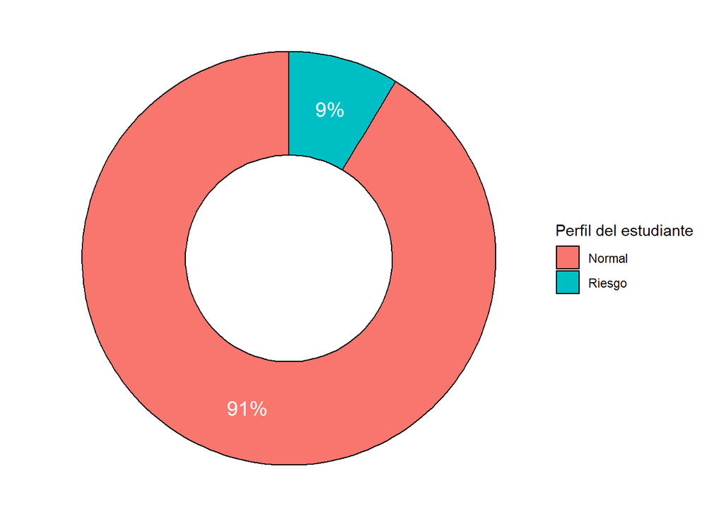

La gran mayoría de los estudiantes se encuentran con un perfil fuera de riesgo.

## Segunda pregunta

### ¿La deserción temprana cómo ha evolucionado a través de las cohortes?

En este caso haremos un análisis bivariado entre nuestra variable dependiente **Deserción** y nuestra variable explicativa **Cohorte**

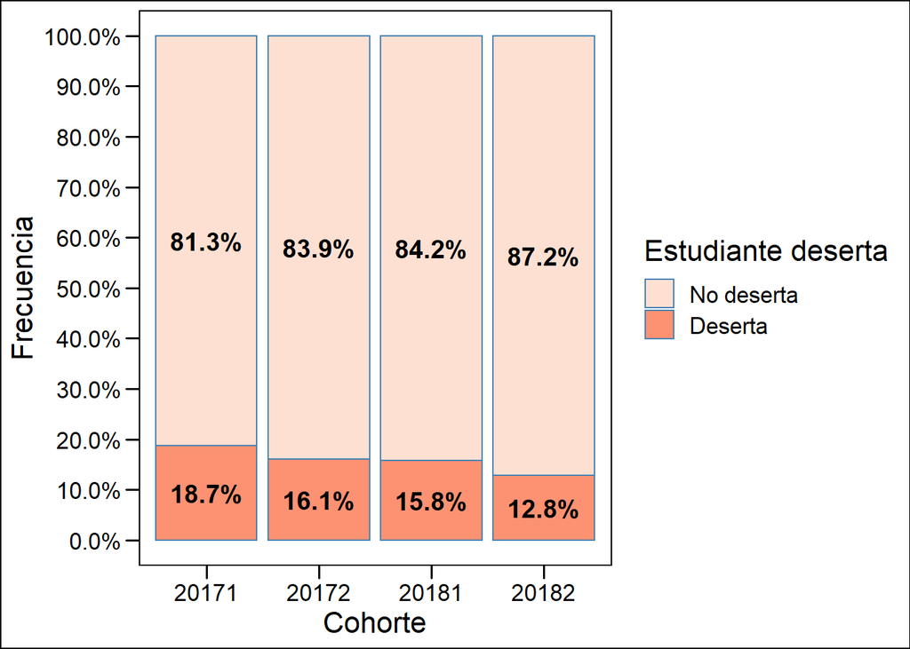

Al parecer la deserción de los estudiantes ha ido disminuyendo a lo largo de los cohortes.

## Tercera pregunta

### ¿Cuáles variables podrían estar relacionadas con la deserción temprana?

#### Deserta y Facultad

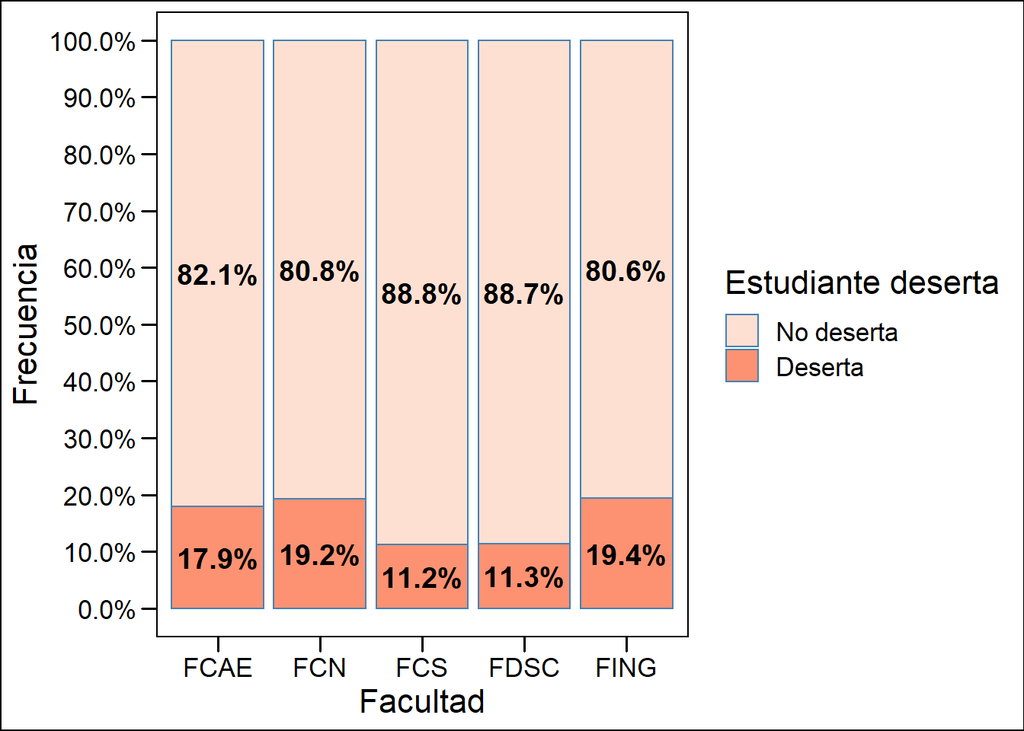

La mayoría de los estudiantes desertores son de la facultad de ingeniería y ciencias naturales, los que menos desiertan son de las facultades de ciencias sociales y FDSC.

#### Deserta y Género

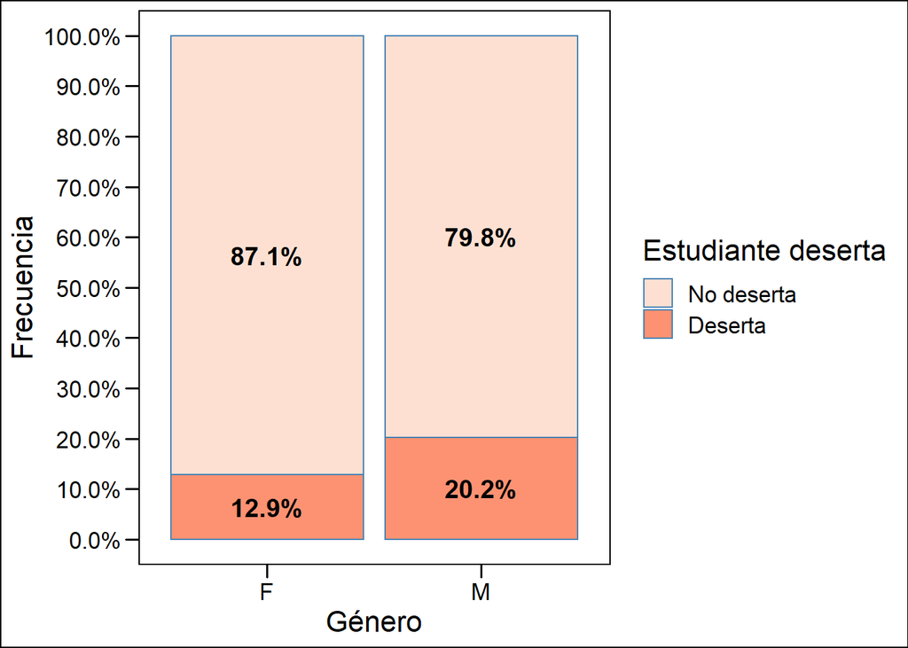

La mayoría de los estudiantes desertores son hombres.

#### Deserta y Estrato

[figure not shown]

Los estudiantes de estratos más altos (5 y 6) son los que más desertan.

#### Deserta y Edad

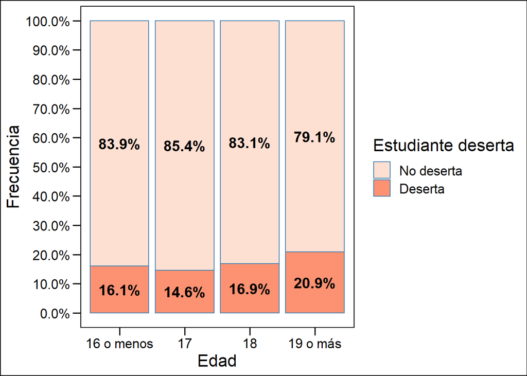

Los estudiantes que más desertan son los que tienen 19 o más años, y los que menos lo hacen son los que tienen 17 años.

#### Deserta y Ciudad Procedencia

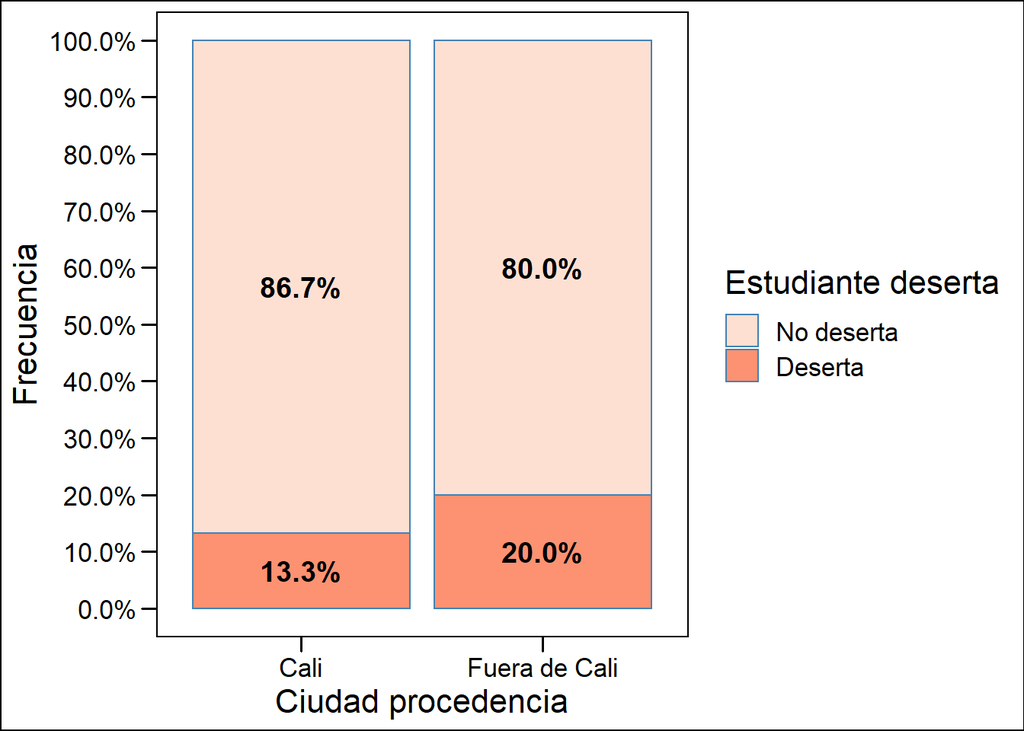

Los estudiantes que no son de Cali son los que más desertan.

#### Deserta y Puntaje Global

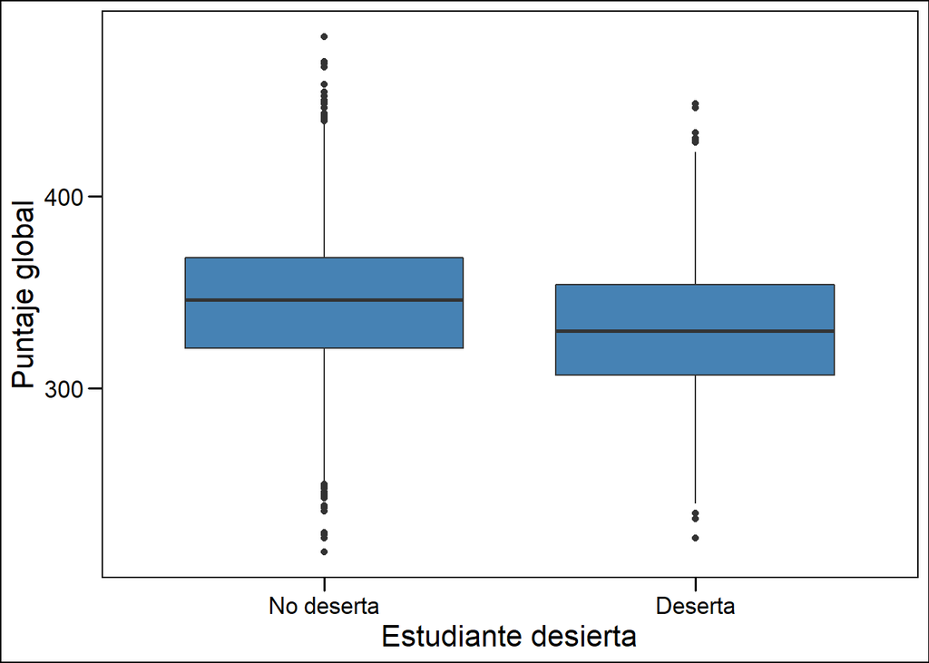

Los estudiantes que más desertan son los que sacan peores notas.

#### Deserta y Riesgo

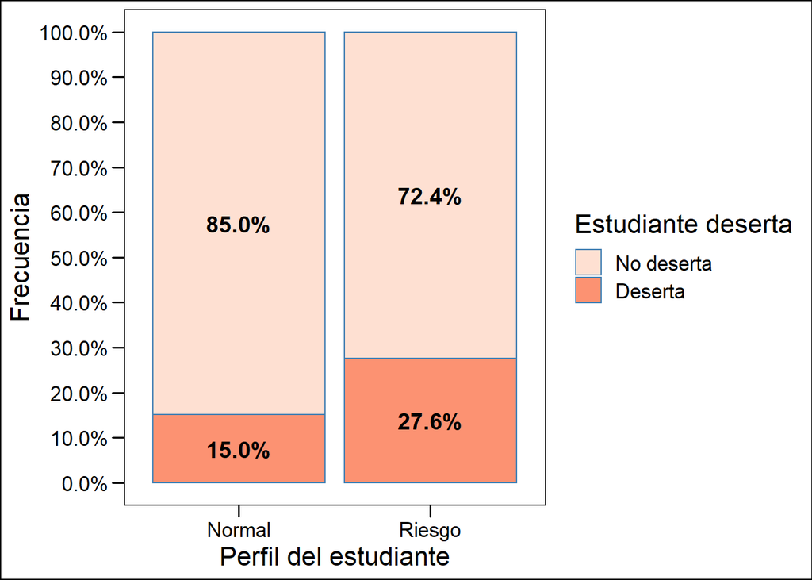

Los estudiantes que tinen un perfil en **Riesgo** son los que más desertan.

**En conclusión** Estas variables explicativas están asociadas a la deserción temprana de los estudiantes: Ser hombre, pertenecer a la facultad de Ingeniería o Ciencias Naturales, estar en los estratos 5 o 6, ser mayor de 19 años, vivir fuera de Cali, sacar peores notas, y tener un perfil en Riesgo está relacionado con la deserción temprana de los estudiantes.